# 1주차 패키지 과제

조혜현

2021 3 8

# **Chapter1**

# 문제 0

```r
library(plyr)
library(tidyverse)
library(data.table)
setwd("C:/Users/iyuo1/OneDrive/Documents/P-SAT/1주차패키지")
data<-fread('data.csv')
```

# 문제 1

## str으로 데이터의 구성을 살펴보고 각 열마다 NA 개수와 unique 값 및 개수를 확인해 보세요.

```r
#str로 데이터 구성 확인
data %>% str()
```

```
## Classes 'data.table' and 'data.frame':   5165 obs. of  8 variables:
##  $ patient_id    :integer64 1000000001 1000000002 1000000003 1000000004 1000000005 1000000006 1000000007 1000000008 ...
##  $ sex           : chr  "male" "male" "male" "male" ...
##  $ age           : chr  "50s" "30s" "50s" "20s" ...
##  $ country       : chr  "Korea" "Korea" "Korea" "Korea" ...
##  $ province      : chr  "서울" "서울" "서울" "서울" ...
##  $ city          : chr  "강서구" "중랑구" "종로구" "마포구" ...
##  $ confirmed_date: IDate, format: "2020-01-23" "2020-01-30" ...
##  $ state         : chr  "released" "released" "released" "released" ...
##  - attr(*, ".internal.selfref")=<externalptr>
```

```r
#각 열마다 NA 갯수 세기
data %>% is.na() %>% colSums()
```

```
##     patient_id            sex            age        country       province
##              0              0              0              0              0
##           city confirmed_date          state
##              0              3              0
```

```r
#각 열마다 unique 값 세기
n_distinct(data)
```

```
## [1] 5165
```

# 문제 2-1

## NA가 있는 행을 삭제하세요.

```r
data<-na.omit(data)
```

# 문제 2-2

## 빈 문자열 이 있 는 행을 삭제하고 각 열마다 NA 개수와 unique 값 및 개수를 다시 확인해 보세요.

```r
#빈 문자열이 있는 행 삭제
data<-data[!(data$patient_id== ''),]
data<-data[!(data$sex== ''),]
data<-data[!(data$age== ''),]
data<-data[!(data$country== ''),]
data<-data[!(data$province== ''),]
data<-data[!(data$city== ''),]
data<-data[!(data$state== ''),]

#각 열마다 NA 갯수 세기
data %>% is.na() %>% colSums()
```

```
##     patient_id            sex            age        country       province
##              0              0              0              0              0
##           city confirmed_date          state
##              0              0              0
```

```r
#각 열마다 unique 값 세기
n_distinct(data)
```

```
## [1] 3690
```

# 문제 3

## country가 ‘Korea’인 행만 남긴 다음 country 열을 제거하세요.

```r
#country가 Korea인 행만 남기기
data<-data[(data$country == 'Korea'),]

#country 열 삭제
data<-data[,-4]
```

# 문제4

## province 변수 내 값을 다음과 같이 바꾸세요.

```r
data$province<-
  data$province %>% revalue(c('서울'='서울특별시','부산'='부산광역시','대구'='대구광역시',
                          '인천'='인천광역시', '대전'='대전광역시','세종'='세종특별자치시',
                          '울산'='울산광역시','제주도'='제주특별자치도'))
```

# 문제5

## confirmed_date를 날짜 자료형으로 바꾸세요.

```r
data$confirmed_date <-
data$confirmed_date %>% as.Date(data$confirmed_date)
```

# 문제6

## 확진날짜 별 확진자 수에 대한 파생변수를 만드세요.

```r
data<-
  data %>% group_by(confirmed_date) %>% mutate(confirmed_number=n())
```

# 문제7

## 확진날짜의 주말 여부에 대한 파생변수를 만드세요.

```r
data<- data %>%
     mutate(wday=ifelse(wday(confirmed_date)==1,'주말','주중'))
data<- data %>%
     mutate(wday=ifelse(wday(confirmed_date)==7,'주말','주중'))
```

# 문제8

## 나이대별 일별 확진자 수에 대한 summary를 확인해보세요.

```r
#나이대 별 일별 확진자 수에 대한 분포
a<- data %>% group_by(age,confirmed_date) %>% summarise(n=n())
tapply(a$n,a$age,summary)
```

```
## $`0s`
##    Min. 1st Qu.  Median    Mean 3rd Qu.    Max.
##   1.000   1.000   1.000   1.488   2.000   3.000
##
## $`100s`
##    Min. 1st Qu.  Median    Mean 3rd Qu.    Max.
##       1       1       1       1       1       1
##
## $`10s`
##    Min. 1st Qu.  Median    Mean 3rd Qu.    Max.
##   1.000   1.000   2.000   2.276   3.000   8.000
##
## $`20s`
##    Min. 1st Qu.  Median    Mean 3rd Qu.    Max.
##   1.000   1.000   3.500   7.526  11.000  43.000
##
## $`30s`
##    Min. 1st Qu.  Median    Mean 3rd Qu.    Max.
##   1.000   2.000   3.000   5.051   8.000  17.000
##
## $`40s`
##    Min. 1st Qu.  Median    Mean 3rd Qu.    Max.
##   1.000   1.000   2.000   4.931   6.000  33.000
##
## $`50s`
##    Min. 1st Qu.  Median    Mean 3rd Qu.    Max.
##   1.000   1.000   3.000   6.112   9.000  31.000
##
## $`60s`
##    Min. 1st Qu.  Median    Mean 3rd Qu.    Max.
##   1.000   1.000   3.000   4.722   7.000  22.000
##
## $`70s`
##    Min. 1st Qu.  Median    Mean 3rd Qu.    Max.
##   1.000   1.000   2.000   2.908   3.250  13.000
##
## $`80s`
##    Min. 1st Qu.  Median    Mean 3rd Qu.    Max.
##   1.000   1.000   2.000   3.019   3.750  24.000
##
## $`90s`
##    Min. 1st Qu.  Median    Mean 3rd Qu.    Max.
##   1.000   1.000   1.000   2.286   2.000  16.000
```

# **Chapter2**

# 문제1

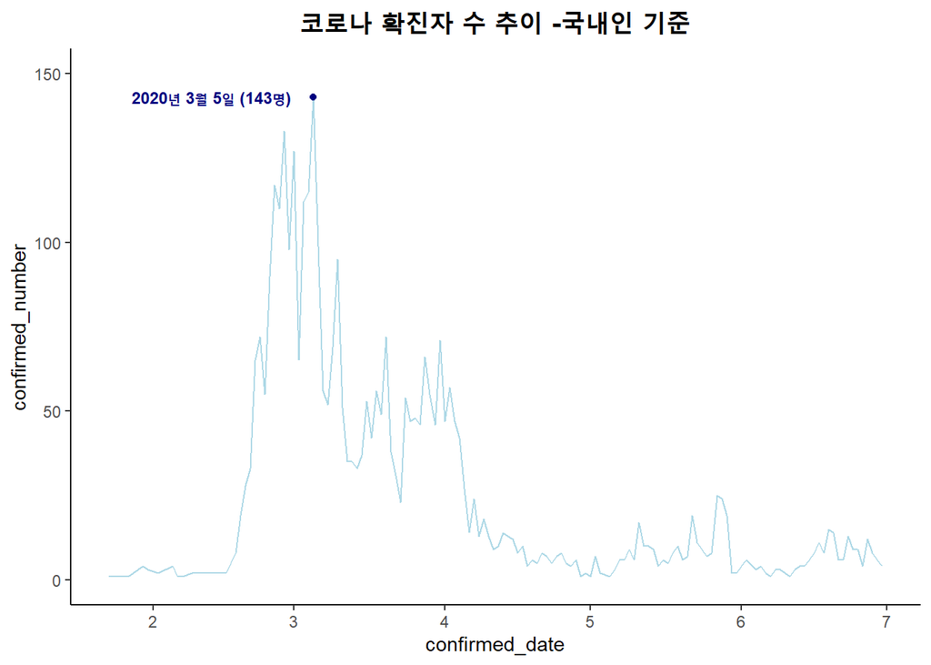

```r
ggplot(data,aes(confirmed_date,confirmed_number))+geom_line(color='lightblue')+ggtitle('코로나 확진자 수 추이 -국내인 기준')+theme_classic()+theme(plot.title=element_text(size=16,hjust=0.5,face='bold'))+geom_point(mapping=aes(x=confirmed_date[which.max(confirmed_number)],y=max(confirmed_number)),color='navy')+coord_cartesian(ylim=c(0,150))+annotate('text',x=as.Date('2020-02-13') ,y=143 ,label='2020년 3월 5일 (143명)',size=3.2,color='navy',fontface=2)
```

```r
#최대 확진자 수 좌표 구하기
#which.max(confirmed_number)
#max(confirmed_number)
```

# 문제1-2

## province별 혹진자 수 추이 그래프를 그리세요.

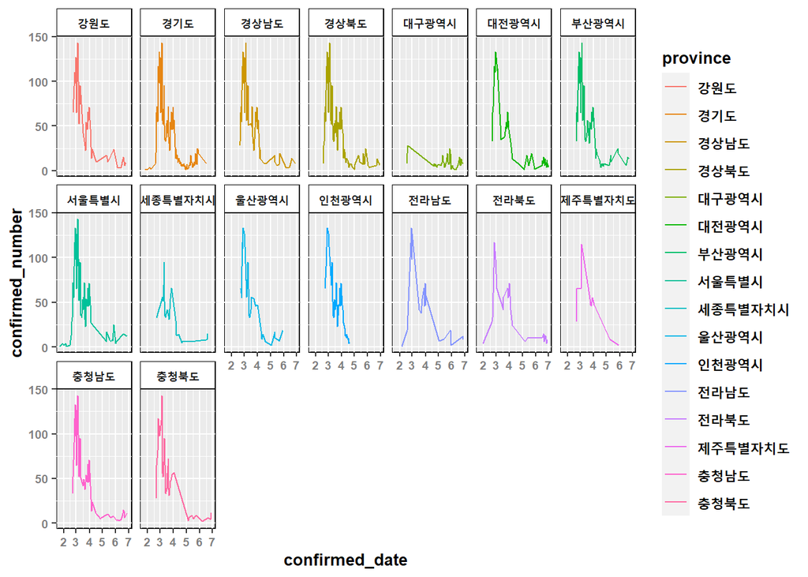

```r
data %>%
  ggplot(aes(x = data$confirmed_date, y = data$confirmed_number, group=province, color=province)) +
  geom_line()+facet_wrap(~province, ncol=7)+
theme(panel.background = element_rect(color='black', linetype='solid'),
        axis.title.x=element_text(face="bold", size=10),
        axis.title.y=element_text(face="bold", size=10),
        plot.title=element_text(face="bold", size=10),
        axis.text.x = element_text(size=7, face="bold", colour = "grey50"),
        axis.text.y = element_text(size=7, face="bold", colour = "grey50"),
        legend.title=element_text(face="bold", size=10),
        legend.text = element_text(face="bold", size=10),
        strip.background = element_rect(fill="white", color="black"),
        strip.text = element_text(face="bold"))+
  labs(x="confirmed_date", y="confirmed_number", color="province")
```

# 문제2

## 지역별 확진자 수를 state(확진자 상황) 그룹 별로 나누어 그래프를 그리세요.

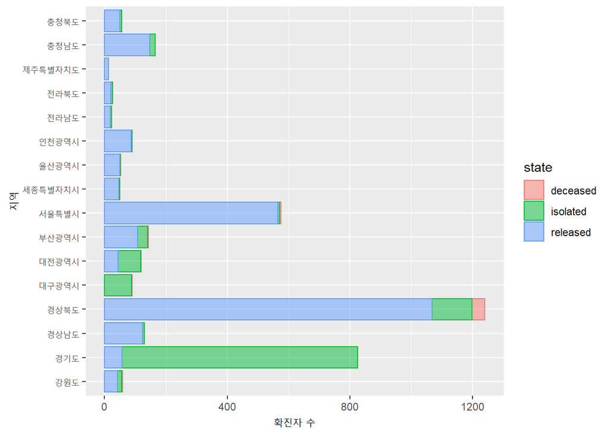

```r
data %>%
  ggplot(aes(factor(province)),group=province,color=state)+geom_bar(aes(fill=state,color=state),alpha=0.5)+labs(x='지역',y='확진자 수')+coord_flip()
```

# 문제3

## 나이대별 일별 확진자 수 box plot을 그리세요.

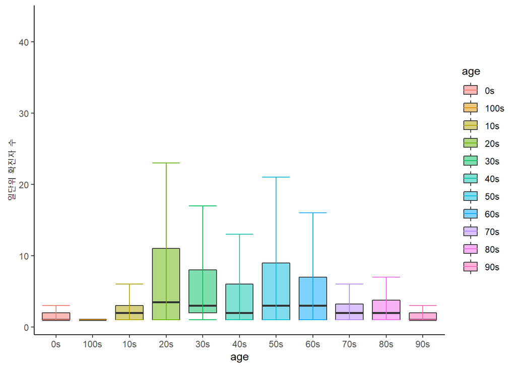

```r
a %>% ggplot(aes(x=age,y=n),group=age,color=age)+geom_boxplot(aes(fill=age),alpha=0.5,outlier.shape = NA)+labs(x='age',y='일단위 확진자 수')+theme_classic()+stat_boxplot(geom='errorbar',aes(color=age))
```

# 문제3-2

## 나이대별 일별 확진자 수에 대한 일원분산분석을 실시하여 해석해보세요.

```r
one<-aov(n~age,a)
summary(one)
```

```
##              Df Sum Sq Mean Sq F value   Pr(>F)
## age          10   2575  257.48   8.823 8.19e-14 ***
## Residuals   780  22764   29.18
## ---
## Signif. codes:  0 '***' 0.001 '**' 0.01 '*' 0.05 '.' 0.1 ' ' 1
```

### p-value가 0.05보다 작으므로 귀무가설을 기각하고, 나이별과 일별 확진자가 서로 dependent한 관계에 있음을 알 수 있다.

# **Chapter3**

# 문제1

## 아래처럼 상관계수 플랏을 만들고 간단히 해석해보세요.

```r
library(MASS)
```

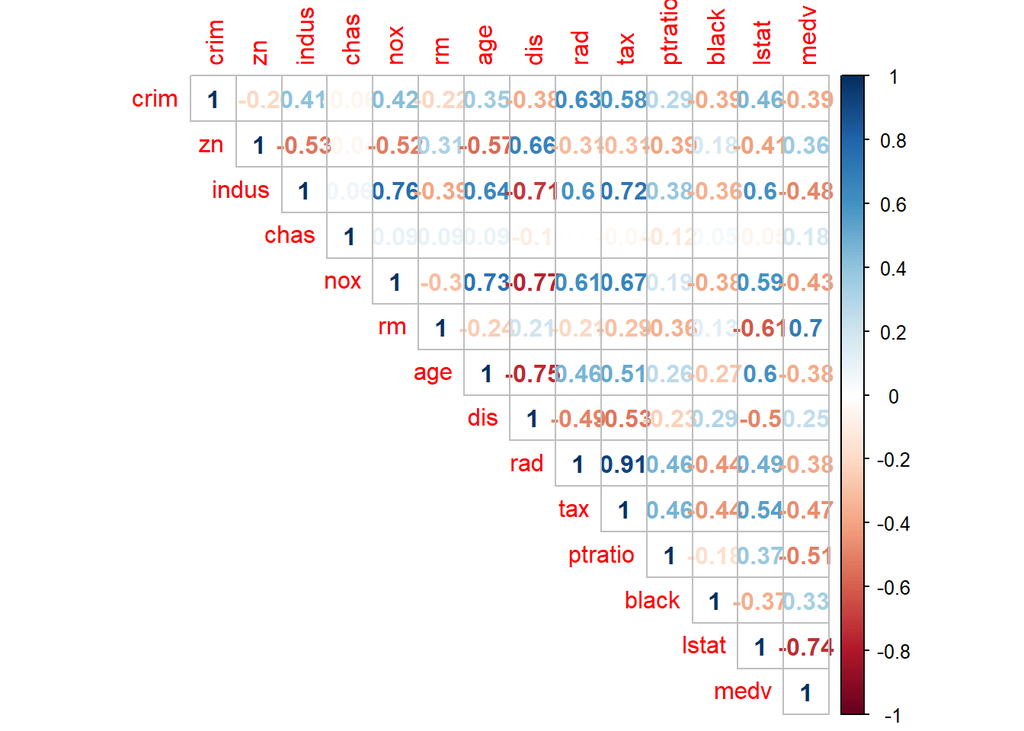

```r
library(corrplot)
library(caret)
library(MLmetrics)
Boston_cor<-cor(Boston)
corrplot(Boston_cor, method="number",type='upper')
```

### 예를 들어 crim과 zn의 상관계수를 보면, -0.2로 음의 상관계수를 나타내고 있다. 이는 crim에서 한 단위의 수가 증가하면, zn에서 0.2만큼 감소함을 의미한다. -1과 +1에 가까울 수록 강한 결합을 갖는데, -0.2는 그리 강한 결합을 가지고 있지 않음을 알 수 있다.

# 문제2

## 아래와 같이 종속변수로 사용할 medv와 이외 변수 간의 관계 파악을 위한 scatter plot 및 회귀 추세선을 그려보세요.

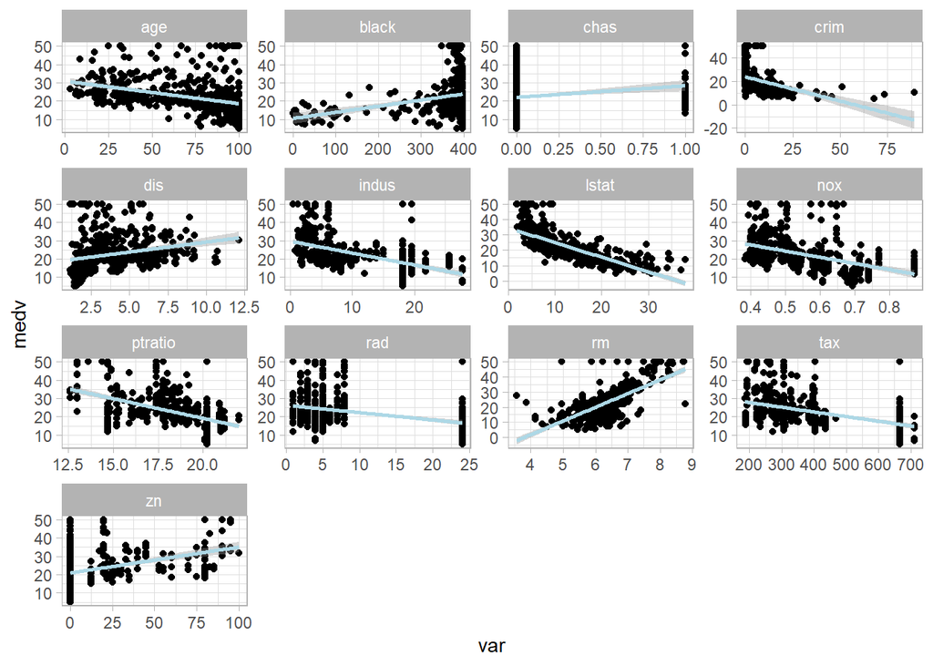

```r
b<-
  Boston %>% gather(var,ab,-medv)

b %>% ggplot(aes(x = ab, y = medv)) +
  geom_point() +
  facet_wrap(~var,scales='free')+labs(x='var',y='medv')+theme_light()+stat_smooth(method=lm,color='lightblue')
```

# 문제3

## 데이터를 train/test데이터를 7:3으로 나누세요.

```r
index <- createDataPartition(Boston$medv,1,0.7,list=FALSE)
train<-Boston[index,]
test<-Boston[-index,]
```

# 문제3-2

## train 데이터로 회귀 모형 만든 후 간단히 결과를 해석한 후, test에 대한 RSME를 구하세요.

```r
model_lm<- lm(medv~.,train)

pred <- predict(model_lm,test)
RMSE(test$medv,pred)
```

```
## [1] 4.534719
```

# 문제3-3

### RMSE를 낯출 수 있는 방법에 대해 간략히 설명해주세요.

### RMSE는 outlier와 연관이 있으므로, 이에 유의해서 outlier를 제거함으로써 예측 모델을 회귀 모델에 가깝게 만든다. 또는 data의 skewness를 줄이는 방법도 있다.

# 문제4

## 적합한 회귀모형의 계수에 대해 아래와 같이 시각화해주세요.

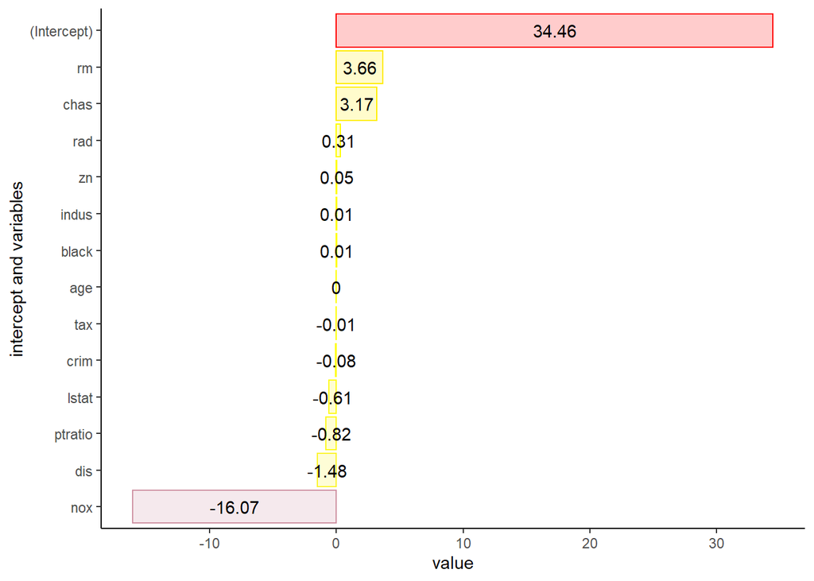

```r
c<-data.frame(var = names(model_lm$coefficients), value = model_lm$coefficients)
c$value<-as.numeric(sprintf('%.2f',model_lm$coefficients))
c %>% ggplot(aes(x=value,y=reorder(var,value),color=value,fill=value))+geom_bar(aes(color=value,fill=value),stat='identity',alpha=0.2)+labs(y='intercept and variables')+scale_fill_gradient2(high='red',mid='yellow',low='blue',guide='legend')+scale_color_gradient2(high='red',mid='yellow',low='blue',guide='legend')+theme_classic()+geom_text(aes(label=value), position = position_stack(vjust=0.5), colour='black')+theme(legend.position='none')
```